# Notebook

Para el cálculo de esta variable es importante tener en cuenta que los préstamos eran a 36 y 60 meses

```python
#creamos una nueva variable con formato fecha
df_const['last_pymnt_date'] = pd.to_datetime(df_const['last_pymnt_d'], format='%b-%y')
df_explot['last_pymnt_date'] = pd.to_datetime(df_explot['last_pymnt_d'], format='%b-%y')
```

```python
#eliminamos la variable string
df_const = df_const.drop(columns=['last_pymnt_d'])
df_explot = df_explot.drop(columns=['last_pymnt_d'])
```

```python
#calculamos los meses transcurridos desde el mes en el que se financió el préstamo hasta fecha en el que el último pago fue recibido
df_const['months_last_pymnt_date'] = ((df_const['last_pymnt_date'] - df_const['issue_date']).dt.days / 30.44).round()
df_explot['months_last_pymnt_date'] = ((df_explot['last_pymnt_date'] - df_explot['issue_date']).dt.days / 30.44).round()
```

```python
#pasamos a integer la nueva variable creada para tener meses enteros
df_const['months_last_pymnt_date'] = df_const['months_last_pymnt_date'].astype(int)
df_explot['months_last_pymnt_date'] = df_explot['months_last_pymnt_date'].astype(int)
```

Las distribuciones de los meses de pagos desde que se financió el préstamo, son muy diferentes para la muestra de construcción y explotación. Aspectos que llaman la atención son:

- En la muestra de construcción se aprecia un fuerte repunte de mes de último pago dentro de los primeros 24 meses. Teniendo en cuenta que gran parte de los préstamos se solicitaron los últimos años (2013 a 2015) y la fecha fin de periodo de observación es 2015, tiene sentido que no hayan trascurrido más de 24 meses desde que se solicitó el préstamo hasta que se tienen registros del último pago.
- También llama la atención el fuerte repunte que en torno a los 36 meses en la muestra de construcción, lo cuál también tiene sentido, puesto la muestra son préstamos consumo a 36 y 60 meses.
- La muestra de explotación, por el contrario muestra una distribución más uniforme, lo cuál es lógico, puesto que dependiendo de cuándo se haya solicitado el préstamo, habrán transcurrido hasta máximo 12 meses a fecha fin de observación (Diciembre 2015).

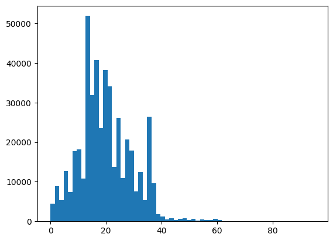

```python
plt.hist(df_const['months_last_pymnt_date'], bins = 60)
```

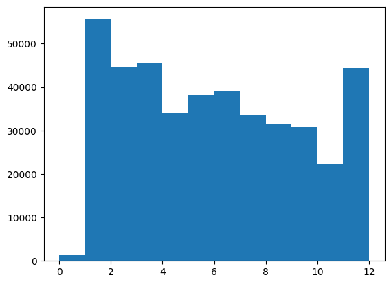

```python
plt.hist(df_explot['months_last_pymnt_date'], bins = 12)
```

```python
#Nos aseguramos que no tenemos valores negativos
df_const['months_last_pymnt_date'].min()
```

```
np.int64(0)
```

```python
df_explot['months_last_pymnt_date'].min()
```

```
np.int64(0)
```

El resultado de la nueva variable creada, serían los meses que han transcurrido entre que se solicitó el préstamo hasta la fecha del último pago recibido. Dicho último pago puede ser por diversos motivos, no sólo por impago. Por ejemplo, el cliente puede haber hecho una amortización total, o puede haber terminado de pagar el préstamo en los meses que le correspondían, o simplemente puede tratarse de la última fecha del periodo de observación.

**7. `last_credit_pull_d`**

Mes más reciente en el Lending Club consultó el crédito para este préstamo

```python
#creamos una nueva variable con formato fecha
df_const['last_credit_pull_date'] = pd.to_datetime(df_const['last_credit_pull_d'], format='%b-%y')
df_explot['last_credit_pull_date'] = pd.to_datetime(df_explot['last_credit_pull_d'], format='%b-%y')
```

```python
#eliminamos la variable string
df_const = df_const.drop(columns=['last_credit_pull_d'])
df_explot = df_explot.drop(columns=['last_credit_pull_d'])
```

```python
#calculamos los meses transcurridos desde que se solicitó el préstamo hasta que Lending Club consultó el crédito para ese préstamo
df_const['months_last_credit_pull_date'] = ((df_const['last_credit_pull_date']-df_const['issue_date']).dt.days / 30.44).round()
df_explot['months_last_credit_pull_date'] = ((df_explot['last_credit_pull_date']-df_explot['issue_date']).dt.days / 30.44).round()
```

```python
#pasamos a integer la nueva variable creada para tener meses enteros
df_const['months_last_credit_pull_date'] = df_const['months_last_credit_pull_date'].astype(int)
df_explot['months_last_credit_pull_date'] = df_explot['months_last_credit_pull_date'].astype(int)
```

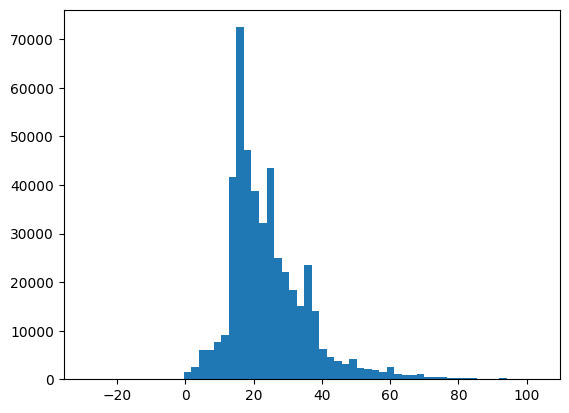

```python
plt.hist(df_const['months_last_credit_pull_date'], bins = 60)
```

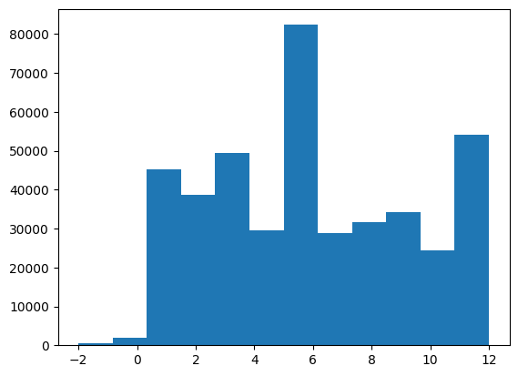

```python
plt.hist(df_explot['months_last_credit_pull_date'], bins = 12)
```

Observamos cómo existen errores de fecha en esta variable, porque que el valor calculado sea negativo significa que la entidad consultó el crédito para ese préstamo antes de que cliente pidiese el préstamo. Por lo que debemos decidir qué hacer con esos valores negativos.

```python
df_const['months_last_credit_pull_date'].min()
df_explot['months_last_credit_pull_date'].min()
```

```
np.int64(-2)
```

```python
df_const[df_const['months_last_credit_pull_date']<0][["last_credit_pull_date", "issue_date"]]
```

|  | last_credit_pull_date | issue_date |
| --- | --- | --- |
| 2202 | 2011-11-01 | 2011-12-01 |
| 10213 | 2011-07-01 | 2011-08-01 |
| 33251 | 2007-08-01 | 2009-12-01 |
| 33261 | 2007-08-01 | 2010-01-01 |
| 33270 | 2007-08-01 | 2009-12-01 |
| ... | ... | ... |
| 362361 | 2014-06-01 | 2014-07-01 |
| 373135 | 2014-06-01 | 2014-07-01 |
| 394535 | 2014-04-01 | 2014-05-01 |
| 405776 | 2014-04-01 | 2014-05-01 |
| 437175 | 2014-02-01 | 2014-03-01 |

100 rows × 2 columns

```python
df_explot[df_explot['months_last_credit_pull_date']<0][["last_credit_pull_date", "issue_date"]]
```

|  | last_credit_pull_date | issue_date |
| --- | --- | --- |
| 28997 | 2015-11-01 | 2015-12-01 |
| 29617 | 2015-11-01 | 2015-12-01 |
| 29998 | 2015-11-01 | 2015-12-01 |
| 34094 | 2015-11-01 | 2015-12-01 |
| 34464 | 2015-11-01 | 2015-12-01 |
| ... | ... | ... |
| 416790 | 2014-12-01 | 2015-01-01 |
| 416996 | 2014-12-01 | 2015-01-01 |
| 417723 | 2014-12-01 | 2015-01-01 |
| 417970 | 2014-12-01 | 2015-01-01 |
| 419538 | 2014-12-01 | 2015-01-01 |

607 rows × 2 columns

**`next_pymnt_d`** --> sólo para explotación (pq en construcción la hemos eliminado)

Próxima fecha de pago programada

```python
#creamos una nueva variable con formato fecha
df_explot['next_pymnt_date'] = pd.to_datetime(df_explot['next_pymnt_d'], format='%b-%y')
```

```python
#eliminamos la variable string
df_explot = df_explot.drop(columns=['next_pymnt_d'])
```

```python
df_explot['months_next_pymnt_date'] = ((df_explot['next_pymnt_date']-df_explot['issue_date']).dt.days / 30.44).round()
```

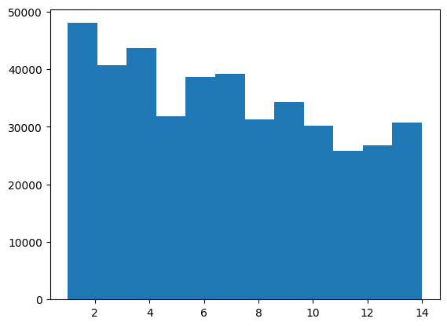

```python
plt.hist(df_explot['months_next_pymnt_date'], bins = 12)
```

```python
df_explot['months_next_pymnt_date'].min()
```

```
np.float64(1.0)
```

### 5. VARIABLES NUMÉRICAS

```python
var_numéricas_const = df_const.select_dtypes(include=['number'])
var_numéricas_const
```

|  | Unnamed: 0 | id | member_id | loan_amnt | funded_amnt | funded_amnt_inv | int_rate | installment | annual_inc | dti | ... | default | term_months | emp_length_years | grade_num | sub_grade_num | verification_status_num | home_ownership_num | months_earliest_cr_line_date | months_last_pymnt_date | months_last_credit_pull_date |
| --- | --- | --- | --- | --- | --- | --- | --- | --- | --- | --- | --- | --- | --- | --- | --- | --- | --- | --- | --- | --- | --- |
| 0 | 0 | 1077501 | 1296599 | 5000 | 5000 | 4975.0 | 10.65 | 162.87 | 24000.0 | 27.65 | ... | 0 | 36 | 10 | 2 | 22 | 2 | 1 | 323 | 37 | 49 |
| 1 | 1 | 1077430 | 1314167 | 2500 | 2500 | 2500.0 | 15.27 | 59.83 | 30000.0 | 1.00 | ... | 1 | 60 | 0 | 3 | 34 | 1 | 1 | 152 | 16 | 21 |
| 2 | 2 | 1077175 | 1313524 | 2400 | 2400 | 2400.0 | 15.96 | 84.33 | 12252.0 | 8.72 | ... | 0 | 36 | 10 | 3 | 35 | 0 | 1 | 121 | 30 | 49 |
| 3 | 3 | 1076863 | 1277178 | 10000 | 10000 | 10000.0 | 13.49 | 339.31 | 49200.0 | 20.00 | ... | 0 | 36 | 10 | 3 | 31 | 1 | 1 | 190 | 37 | 37 |
| 4 | 4 | 1075358 | 1311748 | 3000 | 3000 | 3000.0 | 12.69 | 67.79 | 80000.0 | 17.94 | ... | 0 | 60 | 1 | 2 | 25 | 1 | 1 | 191 | 49 | 49 |
| ... | ... | ... | ... | ... | ... | ... | ... | ... | ... | ... | ... | ... | ... | ... | ... | ... | ... | ... | ... | ... | ... |
| 466280 | 466280 | 8598660 | 1440975 | 18400 | 18400 | 18400.0 | 14.47 | 432.64 | 110000.0 | 19.85 | ... | 0 | 60 | 4 | 3 | 32 | 1 | 3 | 129 | 24 | 24 |
| 466281 | 466281 | 9684700 | 11536848 | 22000 | 22000 | 22000.0 | 19.97 | 582.50 | 78000.0 | 18.45 | ... | 1 | 60 | 10 | 4 | 45 | 2 | 3 | 199 | 11 | 24 |
| 466282 | 466282 | 9584776 | 11436914 | 20700 | 20700 | 20700.0 | 16.99 | 514.34 | 46000.0 | 25.65 | ... | 0 | 60 | 7 | 4 | 41 | 2 | 3 | 145 | 24 | 23 |
| 466283 | 466283 | 9604874 | 11457002 | 2000 | 2000 | 2000.0 | 7.90 | 62.59 | 83000.0 | 5.39 | ... | 0 | 36 | 3 | 1 | 14 | 2 | 2 | 131 | 11 | 15 |
| 466284 | 466284 | 9199665 | 11061576 | 10000 | 10000 | 9975.0 | 19.20 | 367.58 | 46000.0 | 22.78 | ... | 0 | 36 | 10 | 4 | 43 | 2 | 3 | 167 | 24 | 24 |

466285 rows × 43 columns

```python
var_numéricas_explot = df_explot.select_dtypes(include=['number'])
var_numéricas_explot
```

|  | id | member_id | loan_amnt | funded_amnt | funded_amnt_inv | int_rate | installment | annual_inc | dti | delinq_2yrs | ... | term_months | emp_length_years | grade_num | sub_grade_num | verification_status_num | home_ownership_num | months_earliest_cr_line_date | months_last_pymnt_date | months_last_credit_pull_date | months_next_pymnt_date |
| --- | --- | --- | --- | --- | --- | --- | --- | --- | --- | --- | --- | --- | --- | --- | --- | --- | --- | --- | --- | --- | --- |
| 0 | 68444620 | 73334399 | 35000 | 35000 | 35000.0 | 11.99 | 778.38 | 128000.0 | 6.46 | 0.0 | ... | 60 | 10 | 3 | 31 | 1 | 3 | 310 | 1 | 1 | 1.0 |
| 1 | 68547583 | 73437441 | 8650 | 8650 | 8650.0 | 5.32 | 260.50 | 100000.0 | 7.28 | 0.0 | ... | 36 | 0 | 1 | 11 | 0 | 3 | 173 | 1 | 1 | 1.0 |
| 2 | 67849662 | 72708407 | 4225 | 4225 | 4225.0 | 14.85 | 146.16 | 35000.0 | 15.22 | 2.0 | ... | 36 | 5 | 3 | 35 | 1 | 1 | 53 | 1 | 1 | 1.0 |
| 3 | 68506885 | 73396712 | 10000 | 10000 | 10000.0 | 11.99 | 222.40 | 42500.0 | 31.04 | 0.0 | ... | 60 | 10 | 3 | 31 | 0 | 1 | 204 | 1 | 1 | 1.0 |
| 4 | 68341763 | 72928789 | 20000 | 20000 | 20000.0 | 10.78 | 432.66 | 63000.0 | 10.78 | 0.0 | ... | 60 | 10 | 2 | 24 | 0 | 3 | 184 | 1 | 0 | 1.0 |
| ... | ... | ... | ... | ... | ... | ... | ... | ... | ... | ... | ... | ... | ... | ... | ... | ... | ... | ... | ... | ... | ... |
| 421089 | 36371250 | 39102635 | 10000 | 10000 | 10000.0 | 11.99 | 332.10 | 31000.0 | 28.69 | 0.0 | ... | 36 | 8 | 2 | 25 | 2 | 1 | 124 | 12 | 12 | 13.0 |
| 421090 | 36441262 | 39152692 | 24000 | 24000 | 24000.0 | 11.99 | 797.03 | 79000.0 | 3.90 | 0.0 | ... | 36 | 10 | 2 | 25 | 2 | 3 | 490 | 12 | 12 | 13.0 |
| 421091 | 36271333 | 38982739 | 13000 | 13000 | 13000.0 | 15.99 | 316.07 | 35000.0 | 30.90 | 0.0 | ... | 60 | 5 | 4 | 42 | 2 | 1 | 136 | 12 | 12 | 13.0 |
| 421092 | 36490806 | 39222577 | 12000 | 12000 | 12000.0 | 19.99 | 317.86 | 64400.0 | 27.19 | 1.0 | ... | 60 | 1 | 5 | 53 | 1 | 1 | 135 | 12 | 12 | 13.0 |
| 421093 | 36271262 | 38982659 | 20000 | 20000 | 20000.0 | 11.99 | 664.20 | 100000.0 | 10.83 | 0.0 | ... | 36 | 10 | 2 | 25 | 2 | 1 | 157 | 12 | 12 | 13.0 |

421094 rows × 43 columns

```python
var_numéricas_const.columns
```

```
Index(['Unnamed: 0', 'id', 'member_id', 'loan_amnt', 'funded_amnt',
       'funded_amnt_inv', 'int_rate', 'installment', 'annual_inc', 'dti',
       'delinq_2yrs', 'inq_last_6mths', 'open_acc', 'pub_rec', 'revol_bal',
       'revol_util', 'total_acc', 'out_prncp', 'out_prncp_inv', 'total_pymnt',
       'total_pymnt_inv', 'total_rec_prncp', 'total_rec_int',
       'total_rec_late_fee', 'recoveries', 'collection_recovery_fee',
       'last_pymnt_amnt', 'collections_12_mths_ex_med', 'policy_code',
       'acc_now_delinq', 'tot_coll_amt', 'tot_cur_bal', 'total_rev_hi_lim',
       'default', 'term_months', 'emp_length_years', 'grade_num',
       'sub_grade_num', 'verification_status_num', 'home_ownership_num',
       'months_earliest_cr_line_date', 'months_last_pymnt_date',
       'months_last_credit_pull_date'],
      dtype='object')
```

```python
var_numéricas_explot.columns
```

```
Index(['id', 'member_id', 'loan_amnt', 'funded_amnt', 'funded_amnt_inv',
       'int_rate', 'installment', 'annual_inc', 'dti', 'delinq_2yrs',
       'inq_last_6mths', 'open_acc', 'pub_rec', 'revol_bal', 'revol_util',
       'total_acc', 'out_prncp', 'out_prncp_inv', 'total_pymnt',
       'total_pymnt_inv', 'total_rec_prncp', 'total_rec_int',
       'total_rec_late_fee', 'recoveries', 'collection_recovery_fee',
       'last_pymnt_amnt', 'collections_12_mths_ex_med', 'policy_code',
       'acc_now_delinq', 'tot_coll_amt', 'tot_cur_bal', 'total_rev_hi_lim',
       'default', 'term_months', 'emp_length_years', 'grade_num',
       'sub_grade_num', 'verification_status_num', 'home_ownership_num',
       'months_earliest_cr_line_date', 'months_last_pymnt_date',
       'months_last_credit_pull_date', 'months_next_pymnt_date'],
      dtype='object')
```

```python
for var in var_numéricas_const.columns:
    print(f'{var}: {var_numéricas_const[var].nunique()}')
```

```
Unnamed: 0: 466285
id: 466285
member_id: 466285
loan_amnt: 1352
funded_amnt: 1354
funded_amnt_inv: 9854
int_rate: 506
installment: 55622
annual_inc: 31901
dti: 3997
delinq_2yrs: 24
inq_last_6mths: 28
open_acc: 62
pub_rec: 26
revol_bal: 58142
revol_util: 1269
total_acc: 112
out_prncp: 135665
out_prncp_inv: 141189
total_pymnt: 351609
total_pymnt_inv: 347659
total_rec_prncp: 172713
total_rec_int: 270249
total_rec_late_fee: 5808
recoveries: 22773
collection_recovery_fee: 20275
last_pymnt_amnt: 198194
collections_12_mths_ex_med: 9
policy_code: 1
acc_now_delinq: 6
tot_coll_amt: 6321
tot_cur_bal: 220690
total_rev_hi_lim: 14612
default: 2
term_months: 2
emp_length_years: 11
grade_num: 7
sub_grade_num: 35
verification_status_num: 3
home_ownership_num: 4
months_earliest_cr_line_date: 742
months_last_pymnt_date: 84
months_last_credit_pull_date: 110
```

```python
for var in var_numéricas_explot.columns:
    print(f'{var}: {var_numéricas_explot[var].nunique()}')
```

```
id: 421094
member_id: 421094
loan_amnt: 1361
funded_amnt: 1361
funded_amnt_inv: 1365
int_rate: 110
installment: 40447
annual_inc: 26903
dti: 4086
delinq_2yrs: 26
inq_last_6mths: 7
open_acc: 73
pub_rec: 28
revol_bal: 62072
revol_util: 1211
total_acc: 126
out_prncp: 119580
out_prncp_inv: 132674
total_pymnt: 174159
total_pymnt_inv: 183369
total_rec_prncp: 105390
total_rec_int: 129439
total_rec_late_fee: 812
recoveries: 305
collection_recovery_fee: 300
last_pymnt_amnt: 67226
collections_12_mths_ex_med: 10
policy_code: 1
acc_now_delinq: 8
tot_coll_amt: 8350
tot_cur_bal: 230329
total_rev_hi_lim: 10694
default: 2
term_months: 2
emp_length_years: 11
grade_num: 7
sub_grade_num: 35
verification_status_num: 3
home_ownership_num: 4
months_earliest_cr_line_date: 693
months_last_pymnt_date: 13
months_last_credit_pull_date: 15
months_next_pymnt_date: 14
```

5.1 VARIABLES ELIMINADAS

En **construcción**, eliminamos la variable `policy_code` y `application_type` porque sólo tiene un valor y `Unnamed: 0`porque es el índice repetido

```python
df_const = df_const.drop(columns=['policy_code', 'application_type', 'Unnamed: 0'])
```

En **explotación**, sólo eliminamos `policy_code`, ya que `application_type` tiene 2 variables (no sólo 1 como en construcción) y la haremos dummy

```python
df_explot = df_explot.drop(columns=['policy_code'])
```

5.4. OUTLIERS

```python
#las definimos otra vez pq eliminamos la variable 'policy_code'
var_numéricas_const = df_const.select_dtypes(include=['number'])
var_numéricas_const
```

|  | id | member_id | loan_amnt | funded_amnt | funded_amnt_inv | int_rate | installment | annual_inc | dti | delinq_2yrs | ... | default | term_months | emp_length_years | grade_num | sub_grade_num | verification_status_num | home_ownership_num | months_earliest_cr_line_date | months_last_pymnt_date | months_last_credit_pull_date |
| --- | --- | --- | --- | --- | --- | --- | --- | --- | --- | --- | --- | --- | --- | --- | --- | --- | --- | --- | --- | --- | --- |
| 0 | 1077501 | 1296599 | 5000 | 5000 | 4975.0 | 10.65 | 162.87 | 24000.0 | 27.65 | 0.0 | ... | 0 | 36 | 10 | 2 | 22 | 2 | 1 | 323 | 37 | 49 |
| 1 | 1077430 | 1314167 | 2500 | 2500 | 2500.0 | 15.27 | 59.83 | 30000.0 | 1.00 | 0.0 | ... | 1 | 60 | 0 | 3 | 34 | 1 | 1 | 152 | 16 | 21 |
| 2 | 1077175 | 1313524 | 2400 | 2400 | 2400.0 | 15.96 | 84.33 | 12252.0 | 8.72 | 0.0 | ... | 0 | 36 | 10 | 3 | 35 | 0 | 1 | 121 | 30 | 49 |
| 3 | 1076863 | 1277178 | 10000 | 10000 | 10000.0 | 13.49 | 339.31 | 49200.0 | 20.00 | 0.0 | ... | 0 | 36 | 10 | 3 | 31 | 1 | 1 | 190 | 37 | 37 |
| 4 | 1075358 | 1311748 | 3000 | 3000 | 3000.0 | 12.69 | 67.79 | 80000.0 | 17.94 | 0.0 | ... | 0 | 60 | 1 | 2 | 25 | 1 | 1 | 191 | 49 | 49 |
| ... | ... | ... | ... | ... | ... | ... | ... | ... | ... | ... | ... | ... | ... | ... | ... | ... | ... | ... | ... | ... | ... |
| 466280 | 8598660 | 1440975 | 18400 | 18400 | 18400.0 | 14.47 | 432.64 | 110000.0 | 19.85 | 0.0 | ... | 0 | 60 | 4 | 3 | 32 | 1 | 3 | 129 | 24 | 24 |
| 466281 | 9684700 | 11536848 | 22000 | 22000 | 22000.0 | 19.97 | 582.50 | 78000.0 | 18.45 | 0.0 | ... | 1 | 60 | 10 | 4 | 45 | 2 | 3 | 199 | 11 | 24 |
| 466282 | 9584776 | 11436914 | 20700 | 20700 | 20700.0 | 16.99 | 514.34 | 46000.0 | 25.65 | 0.0 | ... | 0 | 60 | 7 | 4 | 41 | 2 | 3 | 145 | 24 | 23 |
| 466283 | 9604874 | 11457002 | 2000 | 2000 | 2000.0 | 7.90 | 62.59 | 83000.0 | 5.39 | 3.0 | ... | 0 | 36 | 3 | 1 | 14 | 2 | 2 | 131 | 11 | 15 |
| 466284 | 9199665 | 11061576 | 10000 | 10000 | 9975.0 | 19.20 | 367.58 | 46000.0 | 22.78 | 1.0 | ... | 0 | 36 | 10 | 4 | 43 | 2 | 3 | 167 | 24 | 24 |

466285 rows × 41 columns

```python
var_numéricas_explot = df_explot.select_dtypes(include=['number'])
var_numéricas_explot
```

|  | id | member_id | loan_amnt | funded_amnt | funded_amnt_inv | int_rate | installment | annual_inc | dti | delinq_2yrs | ... | term_months | emp_length_years | grade_num | sub_grade_num | verification_status_num | home_ownership_num | months_earliest_cr_line_date | months_last_pymnt_date | months_last_credit_pull_date | months_next_pymnt_date |
| --- | --- | --- | --- | --- | --- | --- | --- | --- | --- | --- | --- | --- | --- | --- | --- | --- | --- | --- | --- | --- | --- |
| 0 | 68444620 | 73334399 | 35000 | 35000 | 35000.0 | 11.99 | 778.38 | 128000.0 | 6.46 | 0.0 | ... | 60 | 10 | 3 | 31 | 1 | 3 | 310 | 1 | 1 | 1.0 |
| 1 | 68547583 | 73437441 | 8650 | 8650 | 8650.0 | 5.32 | 260.50 | 100000.0 | 7.28 | 0.0 | ... | 36 | 0 | 1 | 11 | 0 | 3 | 173 | 1 | 1 | 1.0 |
| 2 | 67849662 | 72708407 | 4225 | 4225 | 4225.0 | 14.85 | 146.16 | 35000.0 | 15.22 | 2.0 | ... | 36 | 5 | 3 | 35 | 1 | 1 | 53 | 1 | 1 | 1.0 |
| 3 | 68506885 | 73396712 | 10000 | 10000 | 10000.0 | 11.99 | 222.40 | 42500.0 | 31.04 | 0.0 | ... | 60 | 10 | 3 | 31 | 0 | 1 | 204 | 1 | 1 | 1.0 |
| 4 | 68341763 | 72928789 | 20000 | 20000 | 20000.0 | 10.78 | 432.66 | 63000.0 | 10.78 | 0.0 | ... | 60 | 10 | 2 | 24 | 0 | 3 | 184 | 1 | 0 | 1.0 |
| ... | ... | ... | ... | ... | ... | ... | ... | ... | ... | ... | ... | ... | ... | ... | ... | ... | ... | ... | ... | ... | ... |
| 421089 | 36371250 | 39102635 | 10000 | 10000 | 10000.0 | 11.99 | 332.10 | 31000.0 | 28.69 | 0.0 | ... | 36 | 8 | 2 | 25 | 2 | 1 | 124 | 12 | 12 | 13.0 |
| 421090 | 36441262 | 39152692 | 24000 | 24000 | 24000.0 | 11.99 | 797.03 | 79000.0 | 3.90 | 0.0 | ... | 36 | 10 | 2 | 25 | 2 | 3 | 490 | 12 | 12 | 13.0 |
| 421091 | 36271333 | 38982739 | 13000 | 13000 | 13000.0 | 15.99 | 316.07 | 35000.0 | 30.90 | 0.0 | ... | 60 | 5 | 4 | 42 | 2 | 1 | 136 | 12 | 12 | 13.0 |
| 421092 | 36490806 | 39222577 | 12000 | 12000 | 12000.0 | 19.99 | 317.86 | 64400.0 | 27.19 | 1.0 | ... | 60 | 1 | 5 | 53 | 1 | 1 | 135 | 12 | 12 | 13.0 |
| 421093 | 36271262 | 38982659 | 20000 | 20000 | 20000.0 | 11.99 | 664.20 | 100000.0 | 10.83 | 0.0 | ... | 36 | 10 | 2 | 25 | 2 | 1 | 157 | 12 | 12 | 13.0 |

421094 rows × 42 columns

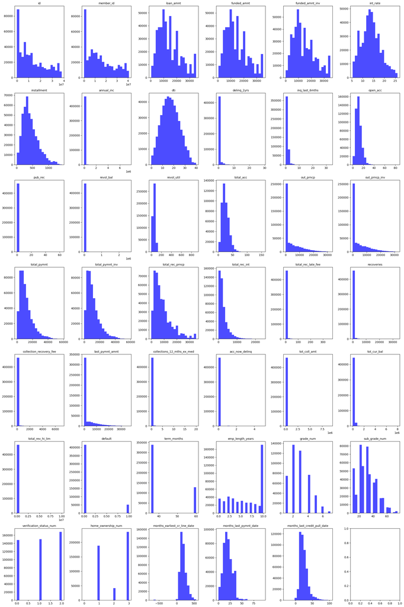

```python
# HISTOGRAMA

num_vars_const = len(var_numéricas_const)
fig, axes = plt.subplots(7, 6, figsize=(20, 30))  # 5 filas x 3 columnas = 15 gráficos
axes = axes.flatten()


for i, col in enumerate(var_numéricas_const):
    if i < len(axes):  # Evitar índice fuera de rango
        axes[i].hist(df_const[col], bins=20, alpha=0.7, color='blue')
        axes[i].set_title(col, fontsize=10)
    else:
        axes[i].axis('off')  # Apagar ejes si sobran subplots

plt.tight_layout()
plt.show()
```

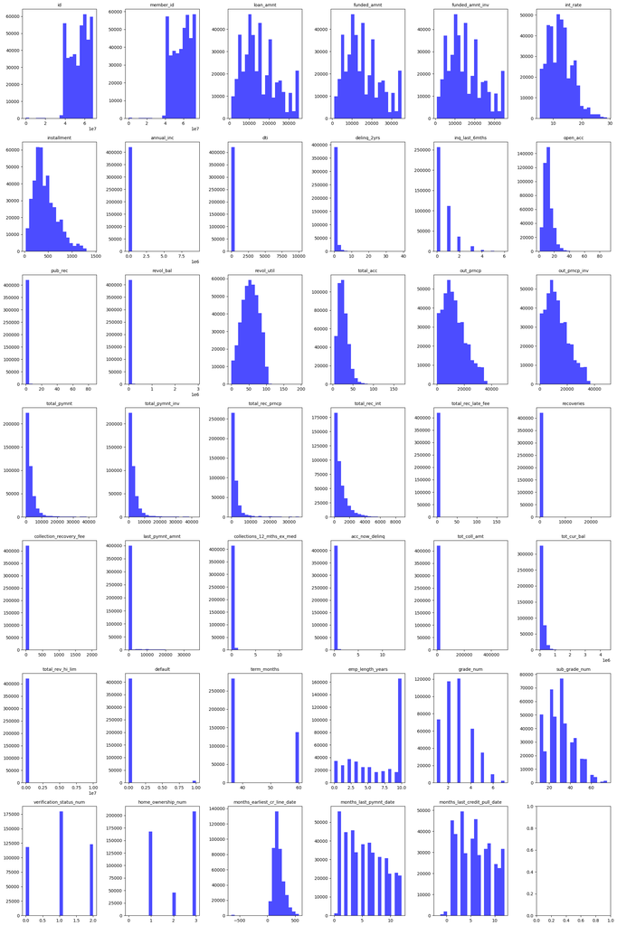

```python
# HISTOGRAMA

num_vars_explot = len(var_numéricas_explot)
fig, axes = plt.subplots(7, 6, figsize=(20, 30))  # 5 filas x 3 columnas = 15 gráficos
axes = axes.flatten()


for i, col in enumerate(var_numéricas_const):
    if i < len(axes):  # Evitar índice fuera de rango
        axes[i].hist(df_explot[col], bins=20, alpha=0.7, color='blue')
        axes[i].set_title(col, fontsize=10)
    else:
        axes[i].axis('off')  # Apagar ejes si sobran subplots

plt.tight_layout()
plt.show()
```

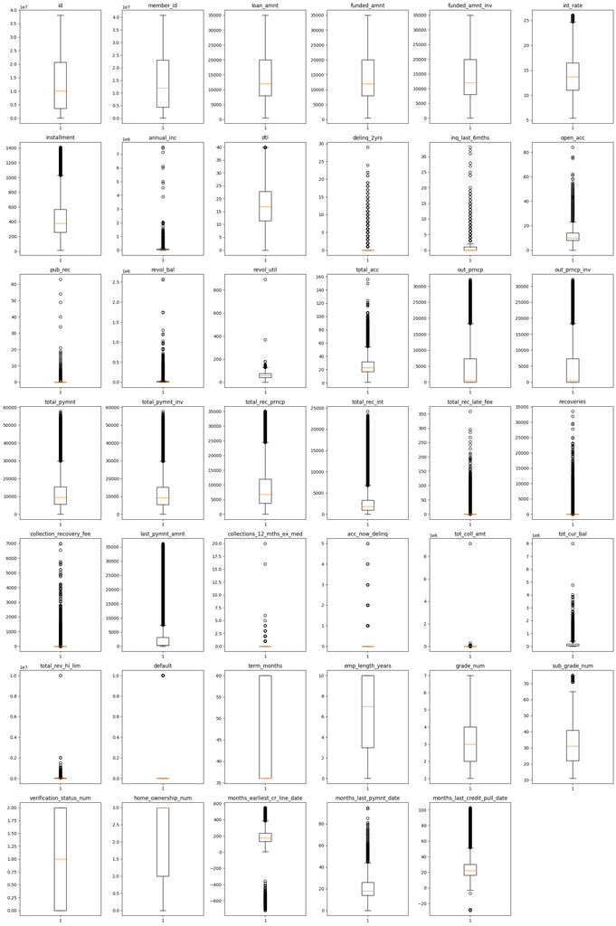

```python
# GRÁFICO DE CAJA

fig, axes = plt.subplots(7, 6, figsize=(20, 30))
axes = axes.flatten()

# Generar los box plots
for i, col in enumerate(var_numéricas_const):
    if col in df_const.columns:  # Verificar si la columna existe en el DataFrame
        if i < len(axes):  # Evitar índice fuera de rango
            axes[i].boxplot(df_const[col].dropna())  # Excluir valores nulos
            axes[i].set_title(col)
    else:
        print(f"Columna no encontrada: {col}")

# Apagar subplots vacíos si hay menos variables que subplots
for j in range(i + 1, len(axes)):
    axes[j].axis('off')

# Ajustar diseño
plt.tight_layout()
plt.show()
```

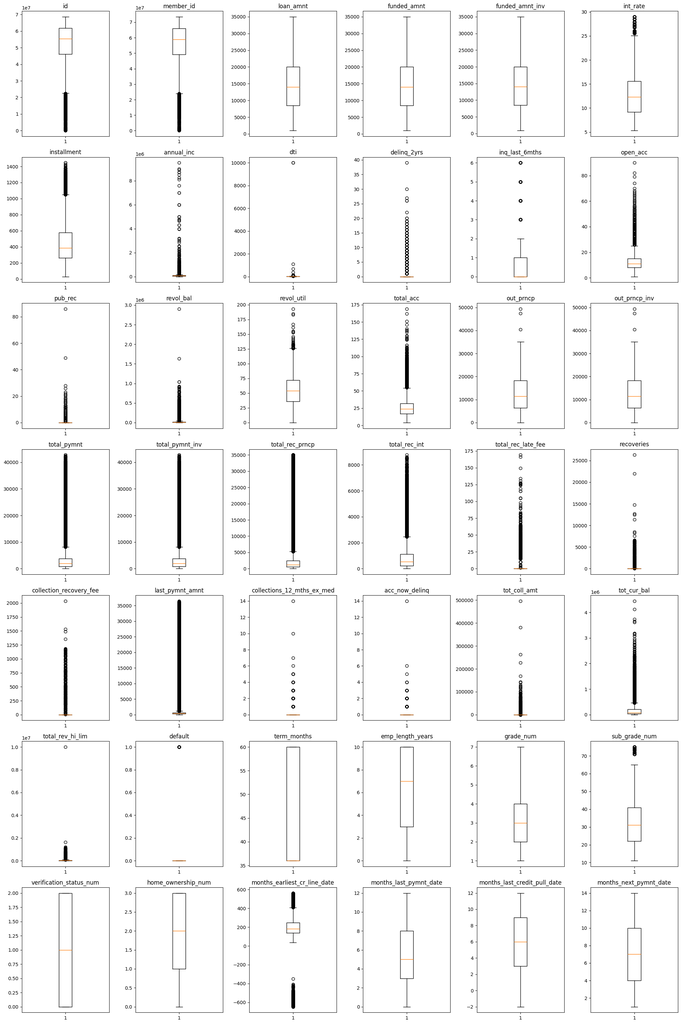

```python
# GRÁFICO DE CAJA

fig, axes = plt.subplots(7, 6, figsize=(20, 30))
axes = axes.flatten()

# Generar los box plots
for i, col in enumerate(var_numéricas_explot):
    if col in df_explot.columns:  # Verificar si la columna existe en el DataFrame
        if i < len(axes):  # Evitar índice fuera de rango
            axes[i].boxplot(df_explot[col].dropna())  # Excluir valores nulos
            axes[i].set_title(col)
    else:
        print(f"Columna no encontrada: {col}")

# Apagar subplots vacíos si hay menos variables que subplots
for j in range(i + 1, len(axes)):
    axes[j].axis('off')

# Ajustar diseño
plt.tight_layout()
plt.show()
```

En los gráficos anteriores observamos muchas variables con outliers. En principio no sabemos si esos valores outliers son valores reales que representan la población (Ej: salario muy alto) o son errores (Ej: salario negativo).  
**Sólo habría que eliminar a los outliers en caso de que se trate realmente de errores.**